# Tandom Power Calculations

### Initialization

```r
library(dplyr)
library(reshape2)
library(ggplot2)

library(pwr)
```

```r
wd <- "/Users/pascaltimshel/Dropbox/011_Work/work-PersLab/2017-01 - TP Tandem Grant power calculation/"
setwd(wd)
```

We start by reading in the data.

```r
### Load data
file.data <- "ADIGEN_metabolomics.csv"
df.raw <- read.table(file.data, header=T, sep=",")
# head(df.raw)
```

We also need to process the data.

### Process data

```r
### Process data
df.data <- df.raw %>% mutate(metaID = paste(df.raw$ID, df.raw$Metabolite.name, sep="|"))
# df.data <- df.data %>% filter(!grepl("Unknown", Metabolite.name)) # if you only want 166 known metabolites.
df.data <- df.data %>% select(metaID, starts_with("X"))

### Melt data
df.data.melt <- melt(df.data, id.vars="metaID")
str(df.data.melt)
```

```
## 'data.frame':    313892 obs. of  3 variables:
##  $ metaID  : chr  "16|3-Hydroxybutyric acid, 2TMS" "24|Alanine, 2TMS" "7|Arachidonic acid, TMS" "18|Aspartic acid, 3TMS" ...
##  $ variable: Factor w/ 388 levels "X4334","X4340",..: 1 1 1 1 1 1 1 1 1 1 ...
##  $ value   : num  52 305.4 42.9 76.4 2400.1 ...
```

### Count

```r
### count number of samples
length(unique(df.data.melt$variable)) # --> 388 samples
```

```
## [1] 388
```

```r
### count number of metabolites
length(unique(df.data.melt$metaID)) # --> 809 metabolites
```

```
## [1] 809
```

### Log-transform data

log2(x+1) transform the data to make the normality assumptions hold.

```r
df.data.melt$value_log2 <- log2(df.data.melt$value+1)
```

### Summary stat calculation

Calculate mean and sd

```r
df.summary <- df.data.melt %>%
  group_by(metaID) %>%
  summarise(mean=mean(value_log2, na.rm=T), sd=sd(value_log2, na.rm=T)) %>%
  arrange(desc(mean))
```

show distribtive stats (median, mean, …)

```r
summary(df.summary)
```

```
##     metaID               mean               sd
##  Length:809         Min.   : 0.1177   Min.   :0.1845
##  Class :character   1st Qu.: 1.4857   1st Qu.:1.1029
##  Mode  :character   Median : 3.0216   Median :1.5149
##                     Mean   : 3.7302   Mean   :1.7123
##                     3rd Qu.: 5.2202   3rd Qu.:2.0452
##                     Max.   :14.1739   Max.   :6.2712
```

### plot distributions of mean and standard deviation

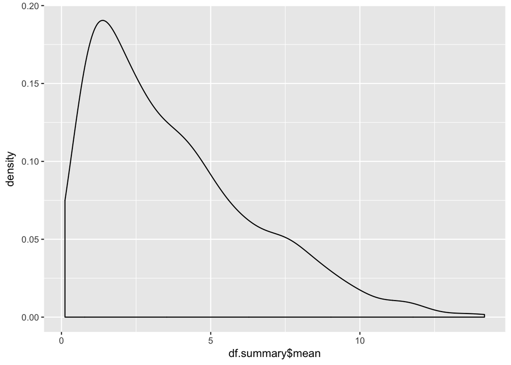

```r
print(qplot(df.summary$mean, geom="density"))
```

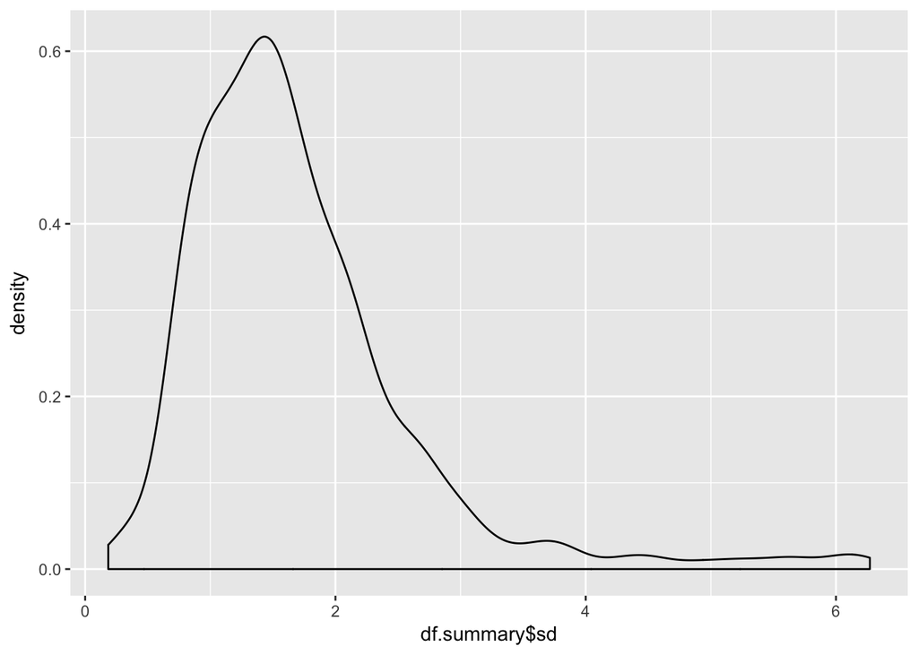

```r
print(qplot(df.summary$sd, geom="density"))
```

### Difference in distribution for known and unknown metabolites

We observe little difference from using only known metabolites to estimate the median variance.

```r
#### STATS for known and unknown metabolites
#     metaID               mean               sd
#  Length:809         Min.   : 0.1177   Min.   :0.1845
#  Class :character   1st Qu.: 1.4857   1st Qu.:1.1029
#  Mode  :character   Median : 3.0216   Median :1.5149   <---
#                     Mean   : 3.7302   Mean   :1.7123
#                     3rd Qu.: 5.2202   3rd Qu.:2.0452
#                     Max.   :14.1739   Max.   :6.2712
#
#### STATS for known metabolites only
#     metaID               mean               sd
#  Length:166         Min.   : 0.4873   Min.   :0.1845
#  Class :character   1st Qu.: 3.0785   1st Qu.:0.8529
#  Mode  :character   Median : 5.7052   Median :1.3347  <---
#                     Mean   : 5.7022   Mean   :1.7671
#                     3rd Qu.: 7.7978   3rd Qu.:2.1486
#                     Max.   :14.1739   Max.   :6.2712
```

# Power Analysis

Power analysis in R: http://www.statmethods.net/stats/power.html

#### Our best estimates of effect size

Cohen, J. (1988) suggests that d values of 0.2, 0.5, and 0.8 represent small, medium, and large effect sizes respectively.

**Pooled variance estimate**: We use the median of the standard deviation for metabolites in the ADIGEN dataset. Since we assume that both groups (time points) have equal variance, the “pooling” does not change the estimation. Hence we set `sigma_pooled = 1.51` on a log2 scale.

**Difference in groups (mu1-mu2)**: We would like to be able to detect to *two-fold increases* in metabolite levels. Let mu_tx denote the metabolite level at time t_x. We have mu_t1=X and mu_t2=2*X. Remember, we work with log-transformed data. We can now write: log2(mu_t2)-log2(mu_t1)=log2(mu_t2/mu_t1)=log2(2*X/X)=log2(2)=1 Hence we set `mu1-mu2=1` on a log2-scale.

```r
p.mudiff <- 1 # log2 scale. this corresponds to a two-fold increase
p.sd <- 1.5149 # log2 scale

p.d <- p.mudiff/p.sd
print(sprintf("Effect size estimate for a two-fold increase in metabolite levels: %s", p.d)) # 0.66010957818998
```

```
## [1] "Effect size estimate for a two-fold increase in metabolite levels: 0.66010957818998"
```

We control the family-wise error using the Bonferroni procedure.

```r
n_metabolites <- 300
alpha_FWER_corrected <- 0.05/n_metabolites
alpha_FWER_corrected
```

```
## [1] 0.0001666667
```

#### Sample size calculations using Cohen’s d suggestions

We see that using the best estimate for the effect size, we need 55.7 individuals at a 80% power level.

```r
# our best estimate for the effect size
pwr.t.test(n=NULL , d=0.66 , sig.level=alpha_FWER_corrected, power=0.8, type="paired", alternative="two.sided")
```

```
##
##      Paired t test power calculation
##
##               n = 55.70991
##               d = 0.66
##       sig.level = 0.0001666667
##           power = 0.8
##     alternative = two.sided
##
## NOTE: n is number of *pairs*
```

```r
# large effect
pwr.t.test(n=NULL , d=0.8 , sig.level=alpha_FWER_corrected, power=0.8, type="paired", alternative="two.sided")
```

```
##
##      Paired t test power calculation
##
##               n = 40.10861
##               d = 0.8
##       sig.level = 0.0001666667
##           power = 0.8
##     alternative = two.sided
##
## NOTE: n is number of *pairs*
```

```r
# medium effect
pwr.t.test(n=NULL , d=0.5 , sig.level=alpha_FWER_corrected, power=0.8, type="paired", alternative="two.sided")
```

```
##
##      Paired t test power calculation
##
##               n = 91.91355
##               d = 0.5
##       sig.level = 0.0001666667
##           power = 0.8
##     alternative = two.sided
##
## NOTE: n is number of *pairs*
```

```r
# small effect
pwr.t.test(n=NULL , d=0.2 , sig.level=alpha_FWER_corrected, power=0.8, type="paired", alternative="two.sided")
```

```
##
##      Paired t test power calculation
##
##               n = 537.5624
##               d = 0.2
##       sig.level = 0.0001666667
##           power = 0.8
##     alternative = two.sided
##
## NOTE: n is number of *pairs*
```

### Plot power curve

Reference: http://www.statmethods.net/stats/power.html

Here we define a function a function to make the power plots for paired t-tests.

```r
plot_power_curve <- function(d) {
  # Plot sample size curves for detecting various effect sizes.

  nd <- length(d)

  # power values
  p <- seq(.4,.9,.1)
  np <- length(p)

  # obtain sample sizes
  samsize <- array(numeric(nd*np), dim=c(nd,np))
  for (i in 1:np){
    for (j in 1:nd){
      result <- pwr.t.test(n=NULL , d=d[j] , sig.level=alpha_FWER_corrected, power=p[i], type="paired", alternative="two.sided")
      samsize[j,i] <- ceiling(result$n)
    }
  }

  # set up graph
  xrange <- range(d)
  yrange <- round(range(samsize))
  colors <- rainbow(length(p))
  p.plot <- plot(xrange, yrange, type="n",
    xlab="Cohen's Effect Size (d)",
    ylab="Sample Size (n)" )

  # add power curves
  for (i in 1:np){
    lines(d, samsize[,i], type="l", lwd=2, col=colors[i])
  }

  # add annotation (grid lines, title, legend)
  abline(v=0, h=seq(0,yrange[2],50), lty=2, col="grey89")
  abline(h=0, v=seq(xrange[1],xrange[2],.02), lty=2,
     col="grey89")
  title("Sample Size Estimation for Paired T-test \n
    Sig=%.2g (Two-tailed)", alpha_FWER_corrected)
  legend("topright", title="Power", as.character(p),
     fill=colors)

  return(p.plot)
}
```

Now we plot the power curves

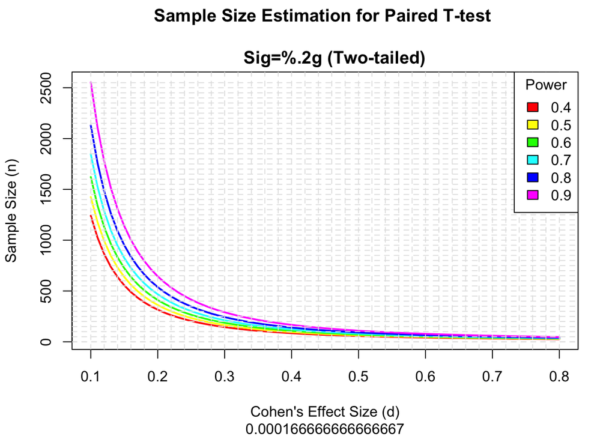

```r
# range of effect size
# d <- seq(.1,.8,.01)
plot_power_curve(seq(.1,.8,.01))
```

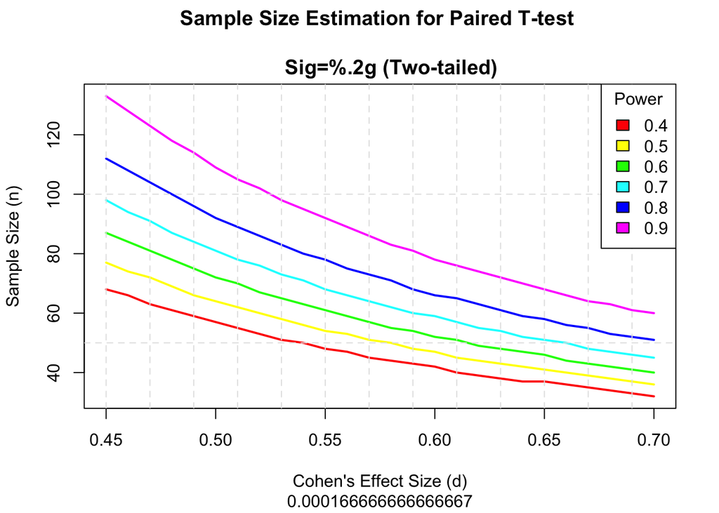

```r
plot_power_curve(seq(.45,.7,.01))
```

```r
# plot_power_curve(seq(.1,.2,.01))
# plot_power_curve(seq(.2,.4,.01))
```

# Appendix

#### Effect size

- Two-sample t-test: Cohen’s d = (mu1-mu2)/sigma_pooled
  - sigma_pooled = … standard pooling procedure …
- Two-sample paired t-test
  - use dz (see below)

**How can I calculate the effect-size for a repeated measures t-test?** Available from: https://www.researchgate.net/post/How_can_I_calculate_the_effect-size_for_a_repeated_measures_t-test [accessed Jan 6, 2017].

1. create a new variable of the differences between both groups (z = Time1 - Time2),
2. obtain the mean (Mz) and standard deviation (SDz) for this new variable,
3. divide Mz by SDz, which will give you the effect size for dependent groups (dz = Mz / SDz)

# References

- Microarray Power Analysis: http://sph.umd.edu/department/epib/sample-size-and-power-calculations-microarray-studies
  - uses multiple hypothesis correction, but a fixed number of “genes”
- Online calculator: http://www.sample-size.net/sample-size-study-paired-t-test/
- Online calculator #2: http://biomath.info/power/